# Investigating IBMA vs GLM

Han Bossier

6 april 2016

## Introduction

In this report, I will zoom in on the differences between performing an image based meta-analysis using the classical tools (converting t-maps to effect sizes and calculate a weighted average based on fixed effects meta-analysis) and dealing with studies on a third level of the typical GLM procedure in an fMRI setting. Hence we get a classical meta-analysis (MA) approach versus a 3 level-GLM (GLM) approach. For more details about both procedures, I refer to the document IBMAvsMA.  
The things we will be considering are:

1. Comparing maps on the second level GLM.
2. Comparing maps on the final level (MA vs GLM).
3. Using COPE and VARCOPE maps from the second level as input in a classical meta-analysis.

> For quick reference, we have **three levels** in this report. The first one are the *subject* specific time series, the second level are *study* specific group analyses and the third level is the *meta-analysis*.

#### Data

In order to obtain results, we simulate fMRI *null* data on a grid of 4 x 4 x 4 voxels. The fMRI analysis consists of one blocked design condition (20 sec ON/OFF) with a TR of 2 sec and a total of 200 scans. Pure white noise only, no between study variability. We have 100 subjects in 5 studies. We start with 3000 simulations.  
Data is being generated in R using neuRosim (for a look at the code, I again refer to the IBMAvsMA report).

## Second level GLM

In this section we can compare the estimates of our effect size (g) with COPE values at the second level GLM. This is mere a check point as the COPE values are linearly related to the effect size! We will only look at the **first study** of the data (which contains 5 studies). Next, we can compare the variance of our estimated effect size (which is calculated using the formula of Radua) with the VARCOPE at the second level. These are not linearly related to each other!

The first two QQ-plots show the distributions of the effect size and the COPE values. The first compares all values over all the 64 voxels and all simulations. The second is an average over all the 3000 simulations. Next we have a density with both distributions.

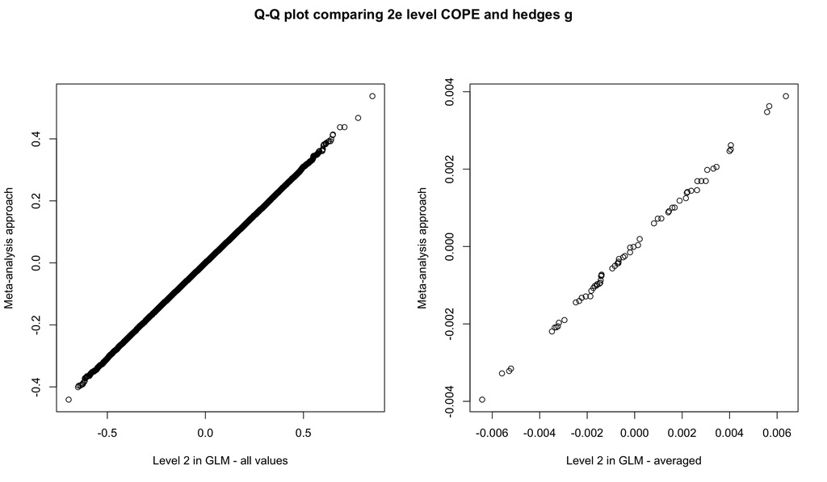

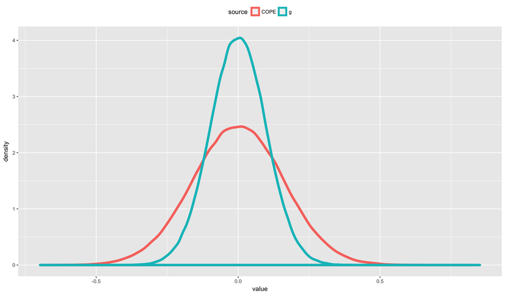

Now we will compare the variance of *g* with the VARCOPES at the second level. Again we start with a QQ-plot with all values, followed by a QQ-plot averaged over the simulations. Then we have a histogram.

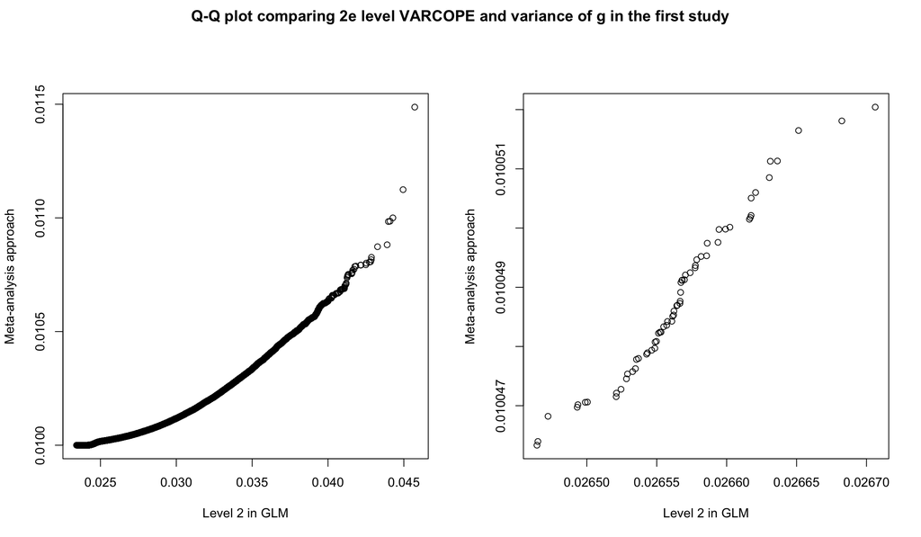

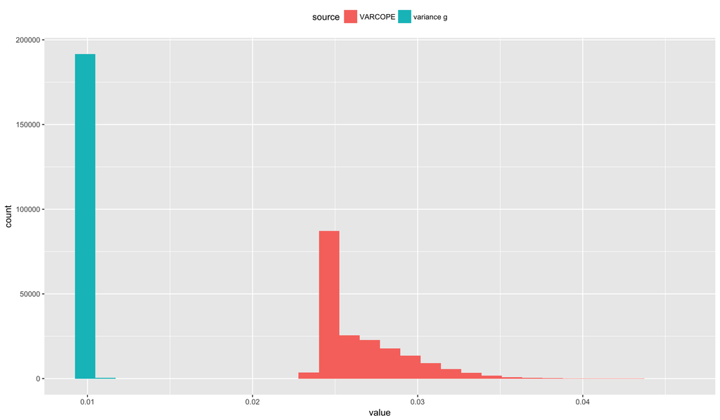

```r
summary(as.numeric(1/stweights))
```

```
##    Min. 1st Qu.  Median    Mean 3rd Qu.    Max.
## 0.01000 0.01000 0.01002 0.01005 0.01006 0.01149
```

```r
summary(as.numeric(varcopeStud))
```

```
##    Min. 1st Qu.  Median    Mean 3rd Qu.    Max.
## 0.02342 0.02451 0.02549 0.02656 0.02803 0.04572
```

We can see how the variance values differ from each other. The distributions do not generally stack well against each other. The variance of our estimated effect size is 1) lower than the VARCOPE values and 2) more evenly distributed (not very visible on the figure) within its range of values.

## Third level GLM

Next, we can look at the third level in the analysis chain. This corresponds to the weighted average in the classical meta-analysis compared to the COPE values at level 3. And then the weighted variance of this estimated weighted average is compared against the VARCOPES at level 3.

We will start again with two QQ-plots (one with all values and one averaged over all simulations) comparing the weighted averages with the COPE maps. We have 3000 times a grid of 64 values (simulations x voxels).

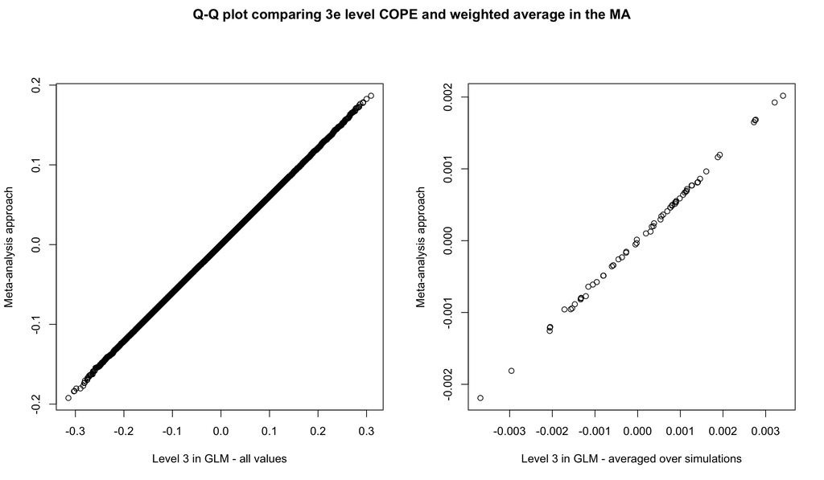

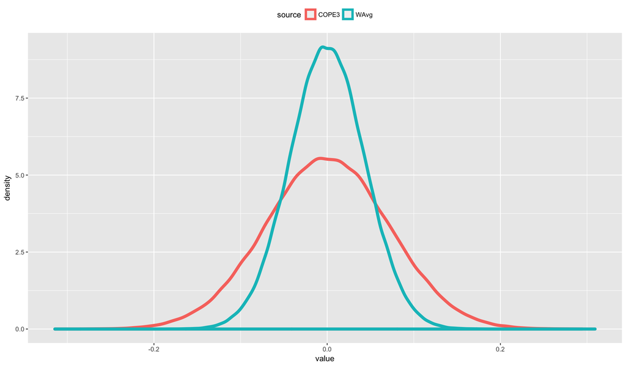

Same for the weighted variance of the estimated weighted average, compared to the VARCOPE maps at level 3.

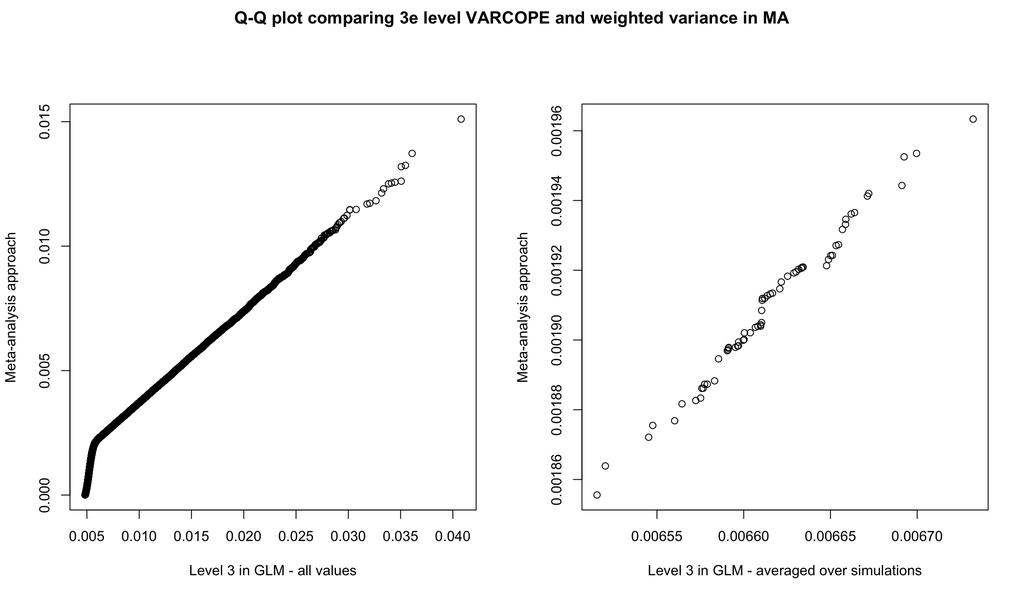

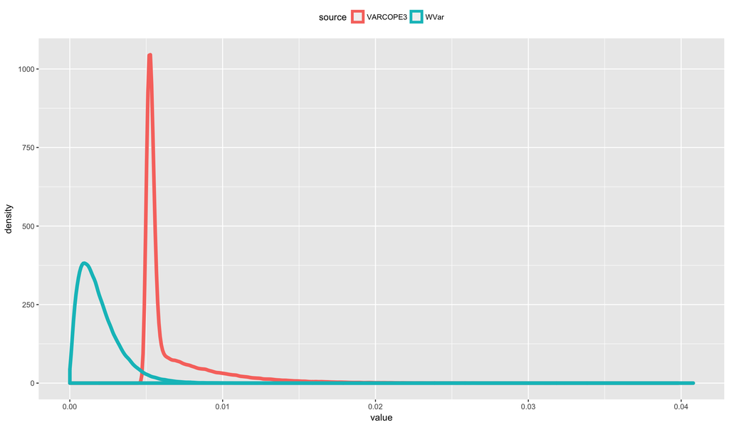

```r
# Summary of the weighted variance of the estimated weighted average
summary(as.numeric(AllData[which(OBJ.ID=='CI.MA.weightedVariance'),]))
```

```
##      Min.   1st Qu.    Median      Mean   3rd Qu.      Max.
## 3.419e-06 9.183e-04 1.606e-03 1.909e-03 2.573e-03 1.510e-02
```

```r
# Summary of the VARCOPE maps
summary(as.numeric(varcopeMA))
```

```
##     Min.  1st Qu.   Median     Mean  3rd Qu.     Max.
## 0.004821 0.005205 0.005447 0.006615 0.006923 0.040790
```

## COPE and VARCOPE ==> Classical Meta-Analysis.

During some of the meetings, the question came up what would happen if we send the COPE and VARCOPE maps at stage 2 to the meta-analysis procedure at stage 3. Hence we get for the weighted average ($\hat{\mu}$):

$$\hat{\mu} = \frac{\sum_i\hat{w_i}\hat{COPE}_i}{\sum_i \hat{w_i}}$$
With $\hat{w_i}$:

$$\hat{w_i} = \frac{1}{\hat{VARCOPE}}$$

We could theoretically construct a CI around this new weighted average by first weighting the VARCOPE images through its inverse ($\hat{w_i}$):
$$\hat{V_w}(\hat{\mu}) = \frac{\sum_i\hat{w_i}(\hat{COPE_i} - \hat{\mu})^2}{(k - 1)\sum_i\hat{w_i}}$$

and then use this estimated variance in:

$$\hat{\mu} \pm t_{k-1,1-\alpha/2}\sqrt{\hat{V_w}(\hat{\mu})}$$

Hence it is possible to calculate the standardized bias of this new weighted average, the length of the CI and the coverage around the true value = 0 (as in the IBMAvsMA report).  
I will define the meta-analysis based on the COPE and VARCOPE maps as *MACV* (meta-analysis based on COPE-VARCOPE) in the figures.

After calculating the *MACV* values, we can already look at both the distributions of MACV and the weighted averages through a classic meta-analysis (using *g* and its variance).

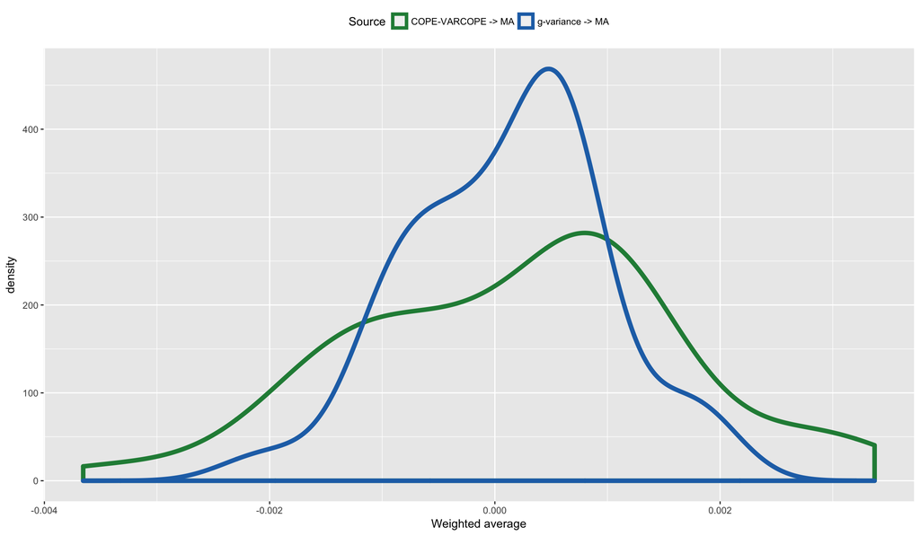

The standardized bias of the 3 analysis chains (MACV, MA and GLM) are depicted next. First we show the averages over all simulations from the 64 voxels. Then averaged over the voxels and simulations.

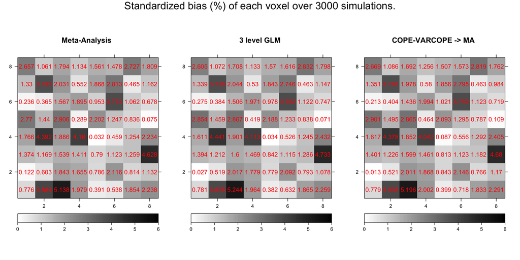

```
##       Mean       SD   CI
## 1 1.670393 1.160742 MACV
## 2 1.653424 1.165159   MA
## 3 1.669985 1.172643  GLM
```

The same can be done for the lenght of the CIs.

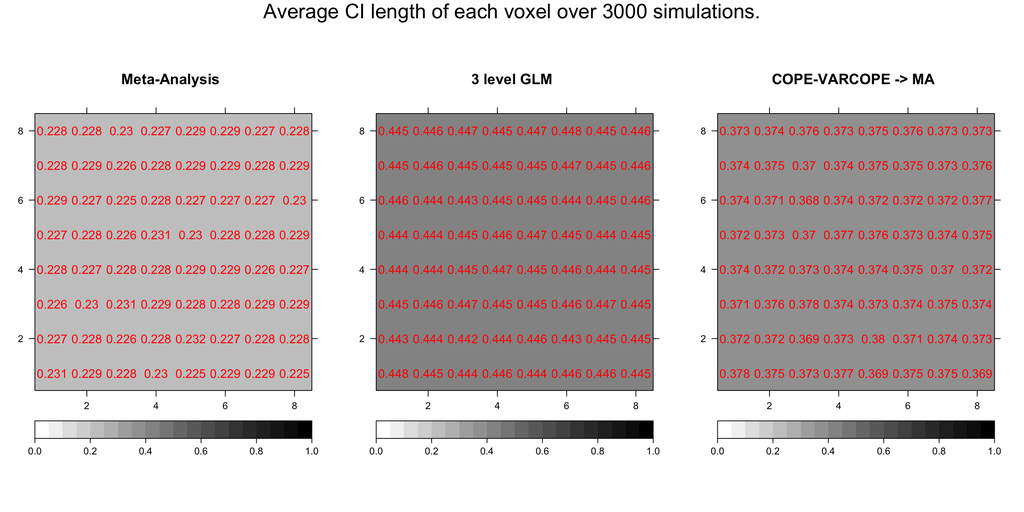

```
##        Mean          SD   CI
## 1 0.3735911 0.002281895 MACV
## 2 0.2280850 0.001396549   MA
## 3 0.4452499 0.001173893  GLM
```

Finally, we look at the average coverage as well.

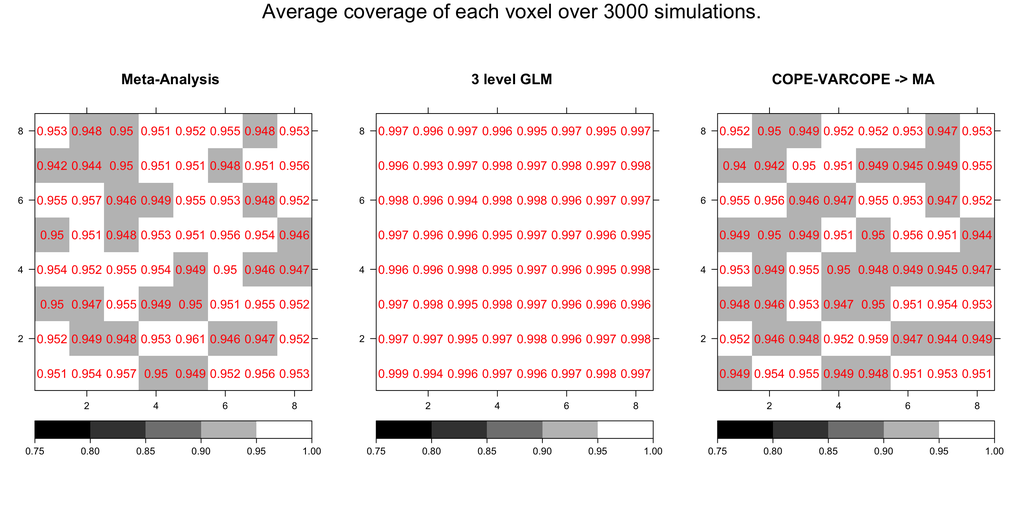

```
##        Mean          SD   CI
## 1 0.9501250 0.003570652 MACV
## 2 0.9511771 0.003475269   MA
## 3 0.9965573 0.001095211  GLM
```